# SliceSamplingExamples

```python
import numpy as np
import matplotlib.pyplot as plt
from scipy.special import gamma
```

**Slice Sampling**

Slice sampling is a MCMC method for sampling a probability distribution. It addresses one of the drawbacks of Metropolis-Hastings by adapting the step size according to the target distribution.

[Radford M. Neal. Slice sampling. Ann. Statist. 31 (3) 705 - 767, June 2003](https://doi.org/10.1214/aos/1056562461)

The following paper compares metropolis-hastings vs slice sampling

[Denny Dittmar, Slice Sampling, TU Darmstadt](https://www.ias.informatik.tu-darmstadt.de/uploads/Teaching/RobotLearningSeminar/Dittmar_RLS_2013.pdf)

We illustrate slice sampling in the following cells

```python
def SliceSamplerStep(x,w,p):
    u = np.random.uniform(0,p(x))
    upr = np.random.random()
    #Defines an interval
    xmin = x - upr*w
    xmax = xmin + w
    #"Steps out" accordingly
    while u < p(xmin):
        xmin = xmin - w
    while u < p(xmax):
        xmax = xmax + w
    while True:
        upr = np.random.random()
        xpr = xmin + upr*(xmax - xmin)
        if u < p(xpr):
            return xpr
        if xpr < x:
            xmin = xpr
        else:
            xmax = xpr
```

```python
#Let us test this for a normal
def phat(x):
    return np.exp(-(x)**2/2)
def p(x):
    return (1/np.sqrt(2*np.pi))*np.exp(-(x)**2/2)
```

```python
samplesize = 100000
w = 0.5
samples = np.zeros(samplesize)
for i in range(1,samplesize):
    samples[i] = SliceSamplerStep(samples[i-1],w,phat)
```

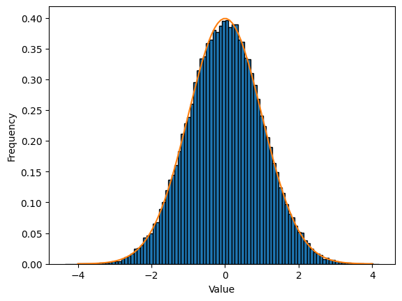

```python
plt.hist(samples, bins=100, edgecolor='black',density=True)
plt.plot(np.linspace(-4,4,100),p(np.linspace(-4,4,100)))
# Add labels and title
plt.xlabel("Value")
plt.ylabel("Frequency")
```

```python
#Let us test this for a Gamma
def phat(x):
    alpha = 7.5
    lam = 1
    return x**(alpha - 1)*np.exp(-lam*x)
def p(x):
    alpha = 7.5
    lam = 1
    return x**(alpha - 1)*np.exp(-lam*x)*lam**(alpha)/gamma(alpha)
```

```python
samplesize = 100000
w = 0.5
samples = np.zeros(samplesize)
for i in range(1,samplesize):
    samples[i] = SliceSamplerStep(samples[i-1],w,phat)
```

[figure not shown]

```python
plt.hist(samples, bins=1000, edgecolor='black',density=True)
plt.plot(np.linspace(0,20,100),p(np.linspace(0,20,100)))
plt.xlim(0,20)
# Add labels and title
plt.xlabel("Value")
plt.ylabel("Frequency")
```

```python
#Let us test this for a Cauchy
def phat(x):
    gam = 0.5
    x0 = 0
    return 1/(1 + ((x - x0)/gam)**2)
def p(x):
    gam = 0.5
    x0 = 0
    return (1/(1 + ((x - x0)/gam)**2))*(1/(np.pi*gam))
```

```python
samplesize = 10000
w = 0.01
samples = np.zeros(samplesize)
for i in range(1,samplesize):
    samples[i] = SliceSamplerStep(samples[i-1],w,phat)
```

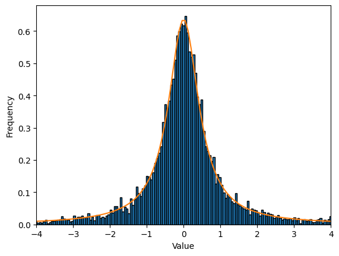

```python
plt.hist(samples, bins=10000, edgecolor='black',density=True)
plt.plot(np.linspace(-4,4,100),p(np.linspace(-4,4,100)))
plt.xlim(-4,4)
# Add labels and title
plt.xlabel("Value")
plt.ylabel("Frequency")
```

Sometimes it may be more stable to do things in logspace. We just leave the code here for future reference.

```python
def LogSliceSamplerStep(x,w,p):
    logu = np.log(p(x)) - np.random.exponential()
    upr = np.random.random()
    xmin = x - upr*w
    xmax = xmin + w
    while logu < np.log(p(xmin)):
        xmin = xmin - w
    while logu < np.log(p(xmax)):
        xmax = xmax + w
    while True:
        upr = np.random.random()
        xpr = xmin + upr*(xmax - xmin)
        if logu < np.log(p(xpr)):
            return xpr
        if xpr < x:
            xmin = xpr
        else:
            xmax = xpr
```

Now let us try Elliptic Slice Sampling. Elliptic Slice Sampling was originally proposed for target distributions like $\pi(x) \sim \mathcal{N}(\mu,\Sigma)L(x)$. It works by randomly sampling $\nu \sim \mathcal{N}(\mu,\Sigma)$ and then uniformly sampling from the ellipse defined by $(x - \mu)cos(\theta) + (\nu - \mu)sin(\theta)$. The union of ellipses for all $\nu$ covers the whole slice thus their is no need to do any "stepping out" as we do for naive slice sampling. We illustrate this union in the final cell.

[1] [Murray, I, Adams, RP & MacKay, DJC 2010, Elliptical slice sampling in (AISTATS)](https://proceedings.mlr.press/v9/murray10a/murray10a.pdf)

[2] [Robert Nishihara, Iain Murray, and Ryan P. Adams. 2014. Parallel MCMC with generalized elliptical slice sampling. J. Mach. Learn. Res. 15, 1 (January 2014), 2087–2112](https://jmlr.org/papers/volume15/nishihara14a/nishihara14a.pdf)

The second paper extends the method to any arbitrary distribution.

```python
def EllipticSliceSampler(x,mu,Sig,L):
    nu = np.random.normal(mu,Sig)
    u = np.random.random()
    logy = np.log(L(x)) + np.log(u)
    theta = np.random.uniform(0,2*np.pi)
    thetamin = theta - 2*np.pi
    thetamax = theta
    loopcounter = 0
    while True:
        xpr = (x - mu)*np.cos(theta) + (nu - mu)*np.sin(theta) + mu
        if logy < np.log(L(xpr)):
            #print(loopcounter)
            return xpr
        else:
            if theta < 0:
                thetamin = theta
            else:
                thetamax = theta
            theta = np.random.uniform(thetamin,thetamax)
        loopcounter += 1
```

```python
#Let us test for the simplest case L(x) = 1 i.e. a normal
#Let us test this for a normal where mu = 0, sigma = 1
def p(x):
    return np.exp(-(x)**2/2)*(1/np.sqrt(2*np.pi))
def L(x):
    return 1
```

```python
samplesize = 10000
samples = np.zeros(samplesize)
for i in range(1,samplesize):
    samples[i] = EllipticSliceSampler(samples[i-1],0,1,L)
```

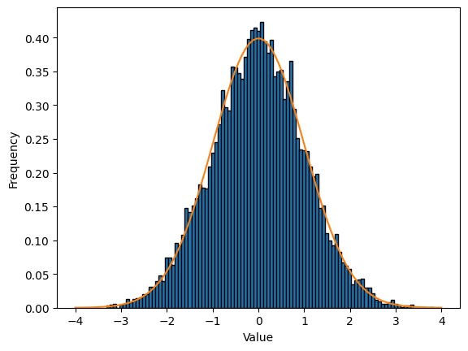

```python
plt.hist(samples, bins=100, edgecolor='black',density=True)
plt.plot(np.linspace(-4,4,100),p(np.linspace(-4,4,100)))
# Add labels and title
plt.xlabel("Value")
plt.ylabel("Frequency")
```

```python
#Let us test for L(x) = e^(-0.1*x**4)
def p(x):
    return (1/(np.sqrt(2*np.pi)*0.85761))*np.exp(-x**2/2 - 0.1*x**4)
def L(x):
    return np.exp(-0.1*x**4)
```

```python
samplesize = 100000
samples = np.zeros(samplesize)
for i in range(1,samplesize):
    samples[i] = EllipticSliceSampler(samples[i-1],0,1,L)
```

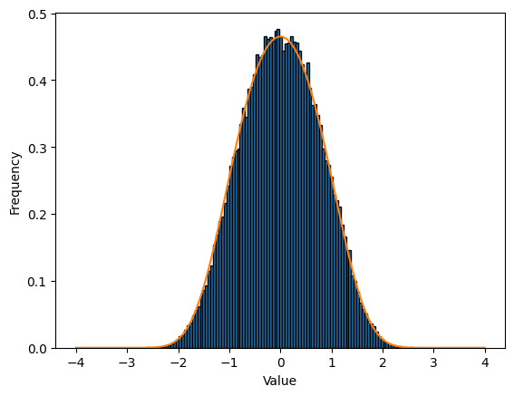

```python
plt.hist(samples, bins=100, edgecolor='black',density=True)
plt.plot(np.linspace(-4,4,100),p(np.linspace(-4,4,100)))
# Add labels and title
plt.xlabel("Value")
plt.ylabel("Frequency")
```

Now let us try to get some intuition for the elliptic slice sampler by showing that the union of all ellipses covers a sufficiently large portion of the slice.

```python
def N(x):
    return np.exp(-(x)**2/2)*(1/(np.sqrt(2*np.pi)))
def p(x):
    return np.exp(-x**2/2 - 0.1*x**4)*(1/(np.sqrt(2*np.pi)*0.85761))
def L(x):
    return np.exp(-0.1*x**4)*(1/(3.223673724312064))
```

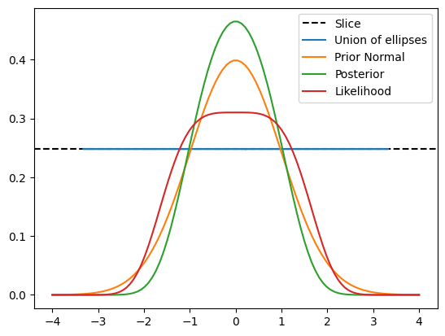

```python
x0 = 0.2
u = 0.8
s = L(x0)*u #This defines a slice
plt.axhline(y=s, color='k', linestyle='--', label='Slice')
unionellipse = np.array(ellipse)
for i in range(100):
    np.random.seed(i)
    nu = np.random.normal(0,1)
    theta = np.random.uniform(0,2*np.pi)
    #These define an ellipse
    thetamin = theta - 2*np.pi
    thetamax = theta
    thetavals = np.linspace(thetamin,thetamax,100)
    ellipse = x0*np.cos(thetavals) + nu*np.sin(thetavals)
    unionellipse = np.append(unionellipse,ellipse)
#The union of ellipses always covers the whole posterior region.
plt.plot(unionellipse,s*np.ones(len(unionellipse)),label='Union of ellipses')
plt.plot(x,N(x),label='Prior Normal')
plt.plot(x,p(x),label='Posterior')
plt.plot(x,L(x),label='Likelihood')
plt.legend()
```